# Tasks

1. **Basic Data Exploration**: Identify the number of rows and columns in the dataset, determine the data types of each column, and check for missing values in each column.
2. **Descriptive Statistics**: Calculate basic statistics mean, median, mode, minimum, and maximum salary, determine the range of salaries, and find the standard deviation.
3. **Data Cleaning**: Handle missing data by suitable method with explain why you use it.
4. **Basic Data Visualization**: Create histograms or bar charts to visualize the distribution of salaries, and use pie charts to represent the proportion of employees in different departments.
5. **Grouped Analysis**: Group the data by one or more columns and calculate summary statistics for each group, and compare the average salaries across different groups.
6. **Simple Correlation Analysis**: Identify any correlation between salary and another numerical column, and plot a scatter plot to visualize the relationship.
7. **Summary of Insights**: Write a brief report summarizing the findings and insights from the analyses.

# 1. Basic Data Exploration

```python
import pandas as pd
import numpy as np
import matplotlib.pyplot as plt
```

```python
# read dataset "Salaries"
df = pd.read_csv('Salaries.csv')
df.head()
```

|  | Id | EmployeeName | JobTitle | BasePay | OvertimePay | OtherPay | Benefits | TotalPay | TotalPayBenefits | Year | Notes | Agency | Status |
| --- | --- | --- | --- | --- | --- | --- | --- | --- | --- | --- | --- | --- | --- |
| 0 | 1 | NATHANIEL FORD | GENERAL MANAGER-METROPOLITAN TRANSIT AUTHORITY | 167411.18 | 0.00 | 400184.25 | NaN | 567595.43 | 567595.43 | 2011 | NaN | San Francisco | NaN |
| 1 | 2 | GARY JIMENEZ | CAPTAIN III (POLICE DEPARTMENT) | 155966.02 | 245131.88 | 137811.38 | NaN | 538909.28 | 538909.28 | 2011 | NaN | San Francisco | NaN |
| 2 | 3 | ALBERT PARDINI | CAPTAIN III (POLICE DEPARTMENT) | 212739.13 | 106088.18 | 16452.60 | NaN | 335279.91 | 335279.91 | 2011 | NaN | San Francisco | NaN |
| 3 | 4 | CHRISTOPHER CHONG | WIRE ROPE CABLE MAINTENANCE MECHANIC | 77916.00 | 56120.71 | 198306.90 | NaN | 332343.61 | 332343.61 | 2011 | NaN | San Francisco | NaN |
| 4 | 5 | PATRICK GARDNER | DEPUTY CHIEF OF DEPARTMENT,(FIRE DEPARTMENT) | 134401.60 | 9737.00 | 182234.59 | NaN | 326373.19 | 326373.19 | 2011 | NaN | San Francisco | NaN |

```python
# Identify the number of rows and columns in the dataset
rows, columns =df.shape
print("number_rows   :", rows )
print("number_columns: ", columns)
```

```
number_rows   : 148654
number_columns:  13
```

```python
# determine the data types of each column
print("Data types of each column:")
print(df.dtypes)
```

```
Data types of each column:
Id                    int64
EmployeeName         object
JobTitle             object
BasePay             float64
OvertimePay         float64
OtherPay            float64
Benefits            float64
TotalPay            float64
TotalPayBenefits    float64
Year                  int64
Notes               float64
Agency               object
Status              float64
dtype: object
```

```python
# check for missing values in each column.
print("Missing values in each column:")
print(df.isnull().sum())
```

```
Missing values in each column:
Id                       0
EmployeeName             0
JobTitle                 0
BasePay                609
OvertimePay              4
OtherPay                 4
Benefits             36163
TotalPay                 0
TotalPayBenefits         0
Year                     0
Notes               148654
Agency                   0
Status              148654
dtype: int64
```

# 2. Descriptive Statistics

```python
#Calculate basic statistics mean, median, mode, minimum, and maximum salary

mean_salary = df['TotalPay'].mean()
median_salary = df['TotalPay'].median()
mode_salary = df['TotalPay'].mode()[0]
min_salary = df['TotalPay'].min()
max_salary = df['TotalPay'].max()

print("Mean salary    :", mean_salary)
print("Median salary  :", median_salary)
print("Mode salary    :", mode_salary)
print("Minimum salary :", min_salary)
print("Maximum salary :", max_salary)
```

```
Mean salary    : 74768.321971703
Median salary  : 71426.60999999999
Mode salary    : 0.0
Minimum salary : -618.13
Maximum salary : 567595.43
```

```python
# determine the range of salaries
salary_range = max_salary - min_salary
print("Salary range: " ,salary_range)
```

```
Salary range:  568213.56
```

```python
# find the standard deviation.
std_salary = df['TotalPay'].std()
print("Standard deviation of salaries:", std_salary)
```

```
Standard deviation of salaries: 50517.005273949944
```

# 3. Data Cleaning

```python
# Simple discovery of dataset for easy cleanup
df.describe()
```

|  | Id | BasePay | OvertimePay | OtherPay | Benefits | TotalPay | TotalPayBenefits | Year | Notes | Status |
| --- | --- | --- | --- | --- | --- | --- | --- | --- | --- | --- |
| count | 148654.000000 | 148045.000000 | 148650.000000 | 148650.000000 | 112491.000000 | 148654.000000 | 148654.000000 | 148654.000000 | 0.0 | 0.0 |
| mean | 74327.500000 | 66325.448841 | 5066.059886 | 3648.767297 | 25007.893151 | 74768.321972 | 93692.554811 | 2012.522643 | NaN | NaN |
| std | 42912.857795 | 42764.635495 | 11454.380559 | 8056.601866 | 15402.215858 | 50517.005274 | 62793.533483 | 1.117538 | NaN | NaN |
| min | 1.000000 | -166.010000 | -0.010000 | -7058.590000 | -33.890000 | -618.130000 | -618.130000 | 2011.000000 | NaN | NaN |
| 25% | 37164.250000 | 33588.200000 | 0.000000 | 0.000000 | 11535.395000 | 36168.995000 | 44065.650000 | 2012.000000 | NaN | NaN |
| 50% | 74327.500000 | 65007.450000 | 0.000000 | 811.270000 | 28628.620000 | 71426.610000 | 92404.090000 | 2013.000000 | NaN | NaN |
| 75% | 111490.750000 | 94691.050000 | 4658.175000 | 4236.065000 | 35566.855000 | 105839.135000 | 132876.450000 | 2014.000000 | NaN | NaN |
| max | 148654.000000 | 319275.010000 | 245131.880000 | 400184.250000 | 96570.660000 | 567595.430000 | 567595.430000 | 2014.000000 | NaN | NaN |

```python
# Delete the two columns (Notes and Status) because they are empty
df = df.drop(['Notes', 'Status'], axis=1)
```

```python
#Delete negative values from data because they are money
df=df[(df['BasePay']>= 0)]
df=df[(df['OvertimePay']>= 0)]
df=df[(df['OtherPay']>= 0)]
df=df[(df['Benefits']>= 0)]
df=df[(df['TotalPay']>= 0)]
df=df[(df['TotalPayBenefits']>= 0)]
```

```python
df.describe()
```

|  | Id | BasePay | OvertimePay | OtherPay | Benefits | TotalPay | TotalPayBenefits | Year |
| --- | --- | --- | --- | --- | --- | --- | --- | --- |
| count | 111868.000000 | 111868.000000 | 111868.000000 | 111868.000000 | 111868.000000 | 111868.000000 | 111868.000000 | 111868.000000 |
| mean | 92327.867245 | 67215.612380 | 5267.136470 | 3655.452223 | 25117.342789 | 76138.201073 | 101255.543862 | 2013.012175 |
| std | 32544.350818 | 43414.618026 | 11765.309871 | 8039.125719 | 15371.434833 | 51266.884806 | 65244.388427 | 0.818014 |
| min | 36160.000000 | 0.000000 | 0.000000 | 0.000000 | 0.000000 | 0.000000 | 0.000000 | 2012.000000 |
| 25% | 64126.750000 | 33665.612500 | 0.000000 | 0.000000 | 12158.642500 | 37064.680000 | 49698.127500 | 2012.000000 |
| 50% | 92113.500000 | 65548.635000 | 0.000000 | 821.100000 | 28699.575000 | 72635.195000 | 101977.380000 | 2013.000000 |
| 75% | 120681.250000 | 95229.030000 | 4867.797500 | 4308.617500 | 35609.472500 | 107541.065000 | 143001.720000 | 2014.000000 |
| max | 148650.000000 | 319275.010000 | 220909.480000 | 342802.630000 | 96570.660000 | 471952.640000 | 510732.680000 | 2014.000000 |

```python
# check for missing values in each column.
print("Missing values in each column:")
print(df.isnull().sum())
```

```
Missing values in each column:
Id                  0
EmployeeName        0
JobTitle            0
BasePay             0
OvertimePay         0
OtherPay            0
Benefits            0
TotalPay            0
TotalPayBenefits    0
Year                0
Agency              0
dtype: int64
```

# 4. Basic Data Visualization

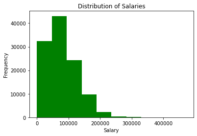

```python
# Create histograms to visualize the distribution of salaries

plt.hist(df['TotalPay'], bins=10, color='green')
plt.xlabel('Salary')
plt.ylabel('Frequency')
plt.title('Distribution of Salaries')
plt.show()
```

```python
# Calculate the number of employees in each department
dept_counts = df['JobTitle'].value_counts()
dept_counts
```

```
Transit Operator                 6975
Special Nurse                    4381
Registered Nurse                 3725
Public Svc Aide-Public Works     2514
Police Officer 3                 2411
                                 ...
Head Airport Electrician            1
Public Service Aide-Technical       1
Asst Chf Prob Ofc, Juv Prob         1
Cashier 3                           1
Conversion                          1
Name: JobTitle, Length: 1109, dtype: int64
```

### Note:

The number of departments is 1109, which is a large number and representing it within a pie chart may not be the best option. Dividing 1109 into ten parts and representing each part in a pie chart may not be effective either. You have tried using other charts such as a bar chart, but it was not good enough. Finally, you used a tree map chart and it was better than the pie chart.

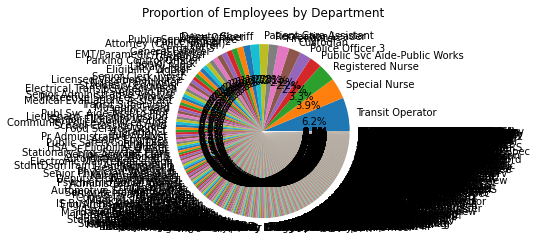

```python
# Create a pie chart to visualize the department proportions
plt.pie(dept_counts, labels=dept_counts.index, autopct='%1.1f%%')
plt.title('Proportion of Employees by Department')
plt.show()
```

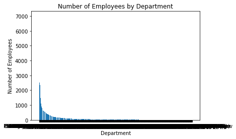

```python
# Create a bar chart to visualize the department counts
plt.bar(dept_counts.index, dept_counts)
plt.title('Number of Employees by Department')
plt.xlabel('Department')
plt.ylabel('Number of Employees')
plt.show()
```

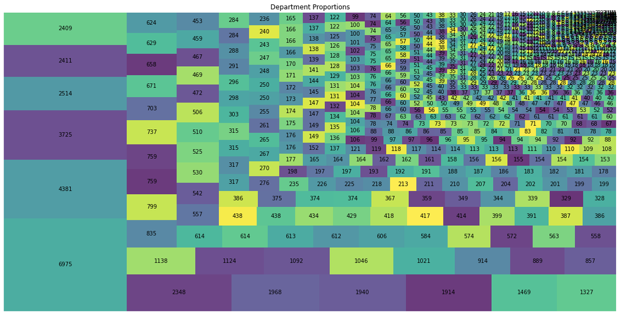

```python
# Create a treemap chart to visualize the department proportions
plt.figure(figsize=(20, 10))
squarify.plot(sizes=dept_counts, label=dept_counts, alpha=.8)
plt.title('Department Proportions')
plt.axis('off')
plt.show()
```

# 5. Grouped Analysis

```python
# Group (Two columns)
# Group the data by job title and calculate the average salary for each group
grouped1 = df.groupby('JobTitle')['TotalPay'].mean()
print(grouped1)
```

```
JobTitle
ACPO,JuvP, Juv Prob (SFERS)        62290.780000
ASR Senior Office Specialist       63519.363167
ASR-Office Assistant               41511.501951
Account Clerk                      43145.753774
Accountant I                       62036.101250
                                      ...
Wire Rope Cable Maint Sprv        203033.720000
Worker's Comp Supervisor 1         70389.297143
Worker's Compensation Adjuster     73249.269865
X-Ray Laboratory Aide              50823.942700
Youth Comm Advisor                 41414.307500
Name: TotalPay, Length: 1109, dtype: float64
```

```python
# Group (Three columns)
# Group the data by year and job title and calculate the total salary for each group
grouped2 = df.groupby(['Year', 'JobTitle'])['TotalPay'].mean()

print(grouped2)
```

```
Year  JobTitle
2012  ASR Senior Office Specialist       59096.911765
      ASR-Office Assistant               40788.172727
      Account Clerk                      46066.717765
      Accountant I                       66632.716667
      Accountant II                      63847.613056
                                            ...
2014  Wire Rope Cable Maint Sprv        190575.900000
      Worker's Comp Supervisor 1         56689.446667
      Worker's Compensation Adjuster     70636.455385
      X-Ray Laboratory Aide              51211.566857
      Youth Comm Advisor                 36465.910000
Name: TotalPay, Length: 3081, dtype: float64
```

# 6. Simple Correlation Analysis

```python
# Calculate the correlation between salary and other numerical columns
all_correlations = df[['BasePay', 'OvertimePay', 'OtherPay', 'Benefits', 'TotalPayBenefits']].corrwith(df['TotalPay'])

print(all_correlations)
```

```
BasePay             0.954791
OvertimePay         0.513831
OtherPay            0.468910
Benefits            0.883360
TotalPayBenefits    0.993885
dtype: float64
```

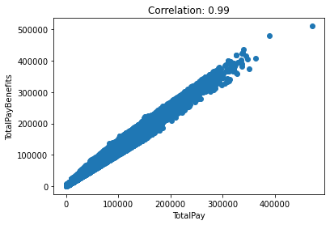

```python
# Calculate the correlation coefficient between "TotalPay" and "TotalPayBenefits"
correlation_TotalPayBenefits = df['TotalPay'].corr(df['TotalPayBenefits'])

# Create a scatter plot to visualize the relationship
plt.scatter(df['TotalPay'], df['TotalPayBenefits'])
plt.xlabel('TotalPay')
plt.ylabel('TotalPayBenefits')
plt.title(f'Correlation: {correlation_TotalPayBenefits:.2f}')
plt.show()
```

As the TotalPayBenefits value increases, the salary value also increases significantly. This relationship is strong and positive if the points scattered on the chart are clearly clustered in the upper right side of the chart.

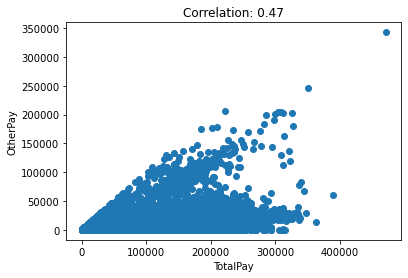

```python
# Calculate the correlation coefficient between "TotalPay" and "OtherPay"
correlation_BasePay = df['TotalPay'].corr(df['OtherPay'])

# Create a scatter plot to visualize the relationship
plt.scatter(df['TotalPay'], df['OtherPay'])
plt.xlabel('TotalPay')
plt.ylabel('OtherPay')
plt.title(f'Correlation: {correlation_BasePay:.2f}')
plt.show()
```

The correlation is 47% and when represented as a sharp angle, this indicates a moderate positive relationship between the columns “TotalPay” and “OtherPay”. In other words, as the value of one variable increases, the value of the other increases significantly, but not dramatically.

# 7.Summary of Insights

Comments, notes, and result explanations have been added to each request separately.

# THE END :)